# 能動的推論による状態遷移学習の導入

**パニック症の回避と曝露のトイシミュレーション**

専修大学大学院文学研究科心理学専攻博士後期課程  
大水 拓海

日本心理学会第90回大会TWS「Pythonによる能動的推論入門」

2026-09-06

# 自己紹介

- **大水拓海(Takumi Omizu)**
- 専修大学大学院文学研究科心理学専攻博士後期課程(D1)
- 心理療法の作用機序や症状維持に関する計算論的アプローチ(心理ネットワーク，確率微分方程式，能動的推論)
- 本発表には生成AIを用いています(シミュレーションコードにGPT-5.6Sol，イラストにGeminiPro)。

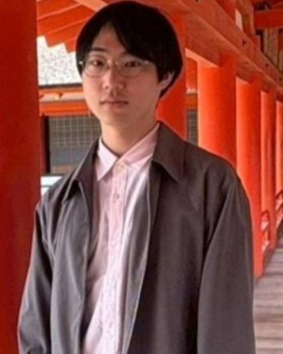

## 目的：心理療法による変化を生成モデルの「学習」として表現する

- $A$（状態→観測）と $B$（状態＋行動→次状態）は，経験によって学習できる。
- 本発表では，とくに **$B$：行動した後にどうなるかという予測の学習** に注目する。
- 方策事前分布 $E$ を操作し，新たな行動(`stay`)の経験機会を増やす。

**パニック症の回避と曝露を念頭に置いたトイモデルで検討する。**

## A行列：身体状態と身体感覚の対応

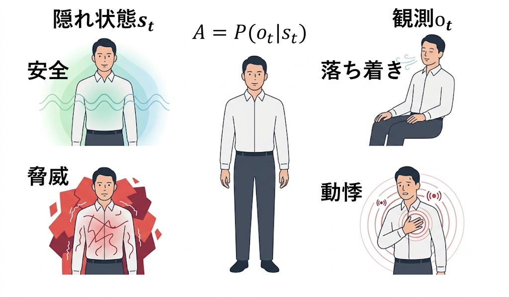

安全と推論している時に落ち着きを経験 ：安全 → 落ち着きが強まる

## B行列の学習：行動後にどうなるかを学ぶ

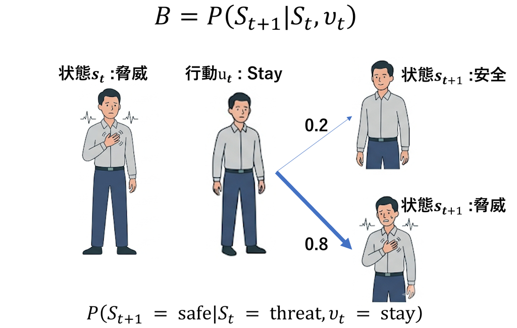

脅威→待機後に安全を経験するほど **「待機しても安全になる」という予測が強まる**

## パニック症の回避と曝露：1試行の流れ

強い動悸の経験：**「身体は安全なのか／生命に関わる危機なのか」**

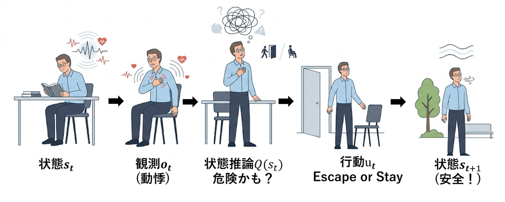

**Q. 回避せず待機する経験は「待機した後どうなるか」という予測Bをどう変えるか？**

## モデルのキーポイント：`stay` の結果を悲観的に予測している

$$P(\mathrm{safe}_{t+1}\mid\mathrm{threat}_t,\mathrm{stay})$$

### エージェントの初期予測

$$\mathbf{0.20}$$

**「脅威状態で留まっても，安全には戻りにくい」**

### 真の環境

$$\mathbf{0.60}$$

実際には，`stay` した後に安全へ移ることがある。

**このずれが，経験によって修正されるかを見る。**

## Simulation 1｜まず，Bは経験だけで学習されるか？

- 100試行，介入なし
- 行動は通常の方策推論から確率的に選択

| 条件 | A learning | B learning |
| --- | --- | --- |
| No learning | × | × |
| A learning | ○ | × |
| B learning | × | ○ |
| A + B learning | ○ | ○ |

**Bが学習されると，`stay` の選択も変わるか？**

## Simulation 1｜Bは学習するが行動は変わらない

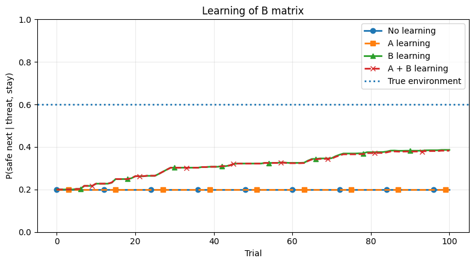

**B learning**

$P(\mathrm{safe}_{t+1}\mid\mathrm{threat}_t,\mathrm{stay})$

**0.20 → 約0.38**

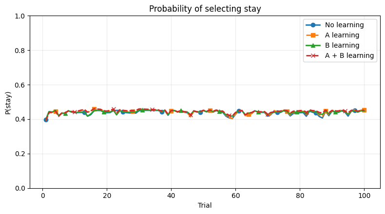

**Stayの選択**

mean $P(\mathrm{stay})$ は **0.438–0.445** とほぼ同じ

**予測は修正されるがモデルの学習だけでは直ちに行動は変わらない。**

## Simulation 2｜`stay` する経験そのものを増やす

$A/B$ を直接変更せず，一定期間だけ**`stay` 方策の選びやすさ**を高める。

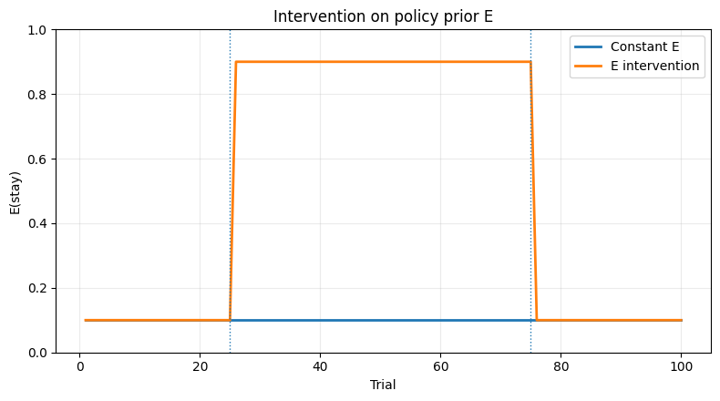

**回避せず留まる経験を得やすくする操作の抽象化**

## Simulation 2｜介入によって `stay` の経験が増える

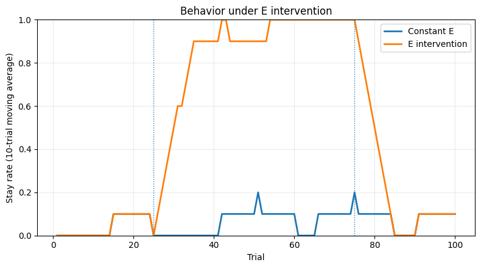

**介入中は `stay` が増え，介入終了後は再び減少する。**

**介入はBを直接書き換えず，学習に使える経験の分布を変える。**

## Simulation 2｜増えた経験がB学習へ波及する

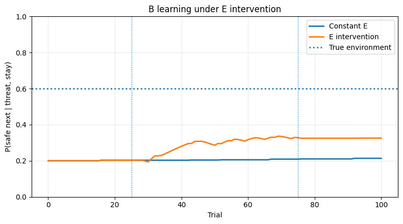

Constant $E$はほぼ **0.20** のまま，$E$ interventionは環境方向にシフト  
介入終了後も，学習したBは保持される。

**新しい経験を得る機会を作ることで，誤った遷移予測が修正される**

→認知を変えるにはまず行動から？

## まとめ

- **Bは「行動した後にどうなるか」という予測**であり，経験によって学習される。
- Bが学習されても，**それだけで行動が大きく変わるとは限らない**。
- $E$ を介して `stay` の経験機会を増やすことで，**経験 → B学習**という介入過程を表現できる。

**能動的推論の枠組みを用いることで，心理療法を「経験を変え，その経験から生成モデルが学習する過程」として検討できる。**